# Lab 6 - Data Manipulation with dbplyr

Quách Đình Hoàng

11/10/2022

## Giới thiệu

Trong bài lab này, bạn sẽ thực hành viết truy vấn CSDL với SQL thông qua thư viện `dbplyr`.

### Lược đồ CSDL

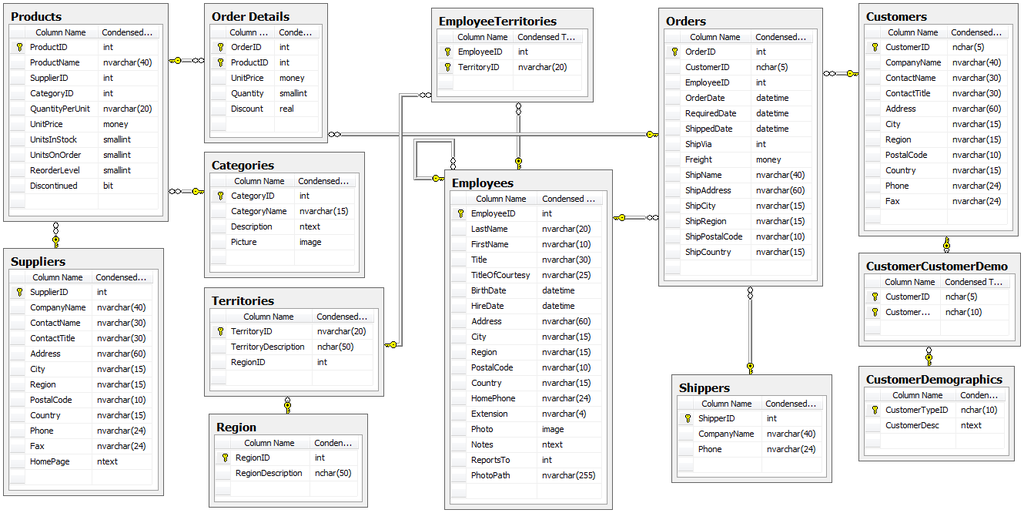

Northwind

### Kết nối đến CSDL

```r
library(DBI)
library(dplyr)
con <- DBI::dbConnect(RSQLite::SQLite(), dbname = "./Northwind2000.db")
DBI::dbListTables(con)
```

```
##  [1] "Categories"           "CustomerCustomerDemo" "CustomerDemographics"
##  [4] "Customers"            "EmployeeTerritories"  "Employees"
##  [7] "Order Details"        "Orders"               "Products"
## [10] "Regions"              "Shippers"             "Suppliers"
## [13] "Territories"          "sqlite_sequence"
```

### Thực hiện một truy vấn đơn giản

```r
query = "SELECT * FROM Shippers"
results <- DBI::dbGetQuery(con, query)
head(results)
```

```
##   ShipperID      CompanyName          Phone
## 1         1   Speedy Express (503) 555-9831
## 2         2   United Package (503) 555-3199
## 3         3 Federal Shipping (503) 555-9931
```

## Câu hỏi

Viết truy vấn SQL cho các câu hỏi bên dưới (thay `query` bằng chuỗi truy vấn SQL thích hợp).

### Q1. Liệt kê `name`, `address`, `city`, và `region` của các `employee` sống ở `'USA'`.

```r
query = "
SELECT firstname, lastname, address,region
FROM Employees WHERE Country ='USA'
"
results <- DBI::dbGetQuery(con, query)
head(results)
```

```
##   FirstName  LastName                   Address Region
## 1     Nancy   Davolio 507 - 20th Ave. E.Apt. 2A     WA
## 2    Andrew    Fuller        908 W. Capital Way     WA
## 3     Janet Leverling        722 Moss Bay Blvd.     WA
## 4  Margaret   Peacock      4110 Old Redmond Rd.     WA
## 5     Laura  Callahan     4726 - 11th Ave. N.E.     WA
```

### Q2. Liệt kê `title` và `name` của các `employee` đã bán ít nhất một `product` có tên `'Gravad Lax'` hoặc `'Mishi Kobe Niku'`.

```r
query = "
SELECT DISTINCT em.Title, em.Firstname ||' ' || em.Lastname AS EmployeeName

FROM Employees em, Orders ord,[Order Details] od, Products pr
WHERE em.EmployeeID=ord.EmployeeID
AND ord.OrderID =od.OrderID
AND od.ProductID=pr.ProductID
AND od.Quantity >=1
AND(pr.ProductName='Gravad Lax'or pr.ProductName='Mishi Kobe Niku')
"
results <- DBI::dbGetQuery(con, query)
results
```

```
##                   Title    EmployeeName
## 1  Sales Representative Janet Leverling
## 2 Vice President, Sales   Andrew Fuller
## 3  Sales Representative  Anne Dodsworth
## 4  Sales Representative     Robert King
```

### Q3. Liệt kê `name` và `title` của các `employee` và `name` và `title` của các `employee` khác mà họ phải báo cáo (`ReportsTo`) (hoặc `null` nếu họ không phải báo cáo với ai).

```r
query = "
select distinct em.Title AS EmployeeTitle ,em.FirstName || ' ' || em.LastName as EmployeeName,
       em1.Title as ManagerTitle,em1.FirstName || ' ' || em1.LastName as ManagerName
from Employees em left join Employees em1 on em.ReportsTo=em1.EmployeeID "
results <- DBI::dbGetQuery(con, query)
results
```

```
##              EmployeeTitle     EmployeeName          ManagerTitle
## 1     Sales Representative    Nancy Davolio Vice President, Sales
## 2    Vice President, Sales    Andrew Fuller                  <NA>
## 3     Sales Representative  Janet Leverling Vice President, Sales
## 4     Sales Representative Margaret Peacock Vice President, Sales
## 5            Sales Manager  Steven Buchanan Vice President, Sales
## 6     Sales Representative   Michael Suyama         Sales Manager
## 7     Sales Representative      Robert King         Sales Manager
## 8 Inside Sales Coordinator   Laura Callahan Vice President, Sales
## 9     Sales Representative   Anne Dodsworth         Sales Manager
##       ManagerName
## 1   Andrew Fuller
## 2            <NA>
## 3   Andrew Fuller
## 4   Andrew Fuller
## 5   Andrew Fuller
## 6 Steven Buchanan
## 7 Steven Buchanan
## 8   Andrew Fuller
## 9 Steven Buchanan
```

### Q4. Liệt kê `customer name`, `product name` và `supplier name` cho các `customer` sống ở `'London'` và các `supplier` có tên `'Pavlova, Ltd.'` hoặc `'Karkki Oy'`.

```r
query = "
select distinct ct.ContactName as CustomerName, pr.ProductName, sp.CompanyName
from Customers ct,Orders od, [Order Details] ord,Products pr,Suppliers sp
where
  ct.CustomerID=od.CustomerID
  and od.OrderID = ord.OrderID
  and ord.ProductID=pr.ProductID
  and sp.SupplierID =pr.SupplierID
  and (sp.CompanyName='Pavlova, Ltd.'or sp.CompanyName='Karkki Oy')
  and ct.City='London'
"
results <- DBI::dbGetQuery(con, query)
results
```

```
##        CustomerName      ProductName   CompanyName
## 1        Hari Kumar          Pavlova Pavlova, Ltd.
## 2      Thomas Hardy Valkoinen suklaa     Karkki Oy
## 3         Ann Devon         Maxilaku     Karkki Oy
## 4      Thomas Hardy    Outback Lager Pavlova, Ltd.
## 5    Simon Crowther    Outback Lager Pavlova, Ltd.
## 6        Hari Kumar     Alice Mutton Pavlova, Ltd.
## 7 Victoria Ashworth    Outback Lager Pavlova, Ltd.
## 8 Victoria Ashworth         Maxilaku     Karkki Oy
## 9        Hari Kumar         Maxilaku     Karkki Oy
```

### Q5. Liệt kê `name` của các `employee` có tuổi lớn hơn **một `employee` nào đó** sống ở `'London'`.

```r
query = "
select firstname || ' ' || lastname as name
from Employees where Employees.City='London' order by BirthDate
"
results <- DBI::dbGetQuery(con, query)
results
```

```
##              name
## 1 Steven Buchanan
## 2     Robert King
## 3  Michael Suyama
## 4  Anne Dodsworth
```

### Q6. Liệt kê `name` của các `employee` có tuổi lớn hơn **tất cả** `employee` sống ở `'London'`.

```r
query = "
 select firstname || ' ' || lastname as EmployeeName
 from Employees where Employees.City='London' order by BirthDate

"
results <- DBI::dbGetQuery(con, query)
head(results)
```

```
##      EmployeeName
## 1 Steven Buchanan
## 2     Robert King
## 3  Michael Suyama
## 4  Anne Dodsworth
```

### Q7. Liệt kê `name` của các `employee` làm việc lâu năm hơn **tất cả** `employee` ở `'London'`.

```r
query = "
SELECT FirstName , LastName
FROM Employees
where HireDate < ( select min(HireDate)
                  from Employees
                    where City == 'London')
"
results <- DBI::dbGetQuery(con, query)
head(results)
```

```
##   FirstName  LastName
## 1     Nancy   Davolio
## 2    Andrew    Fuller
## 3     Janet Leverling
## 4  Margaret   Peacock
```

### Q8. Liệt kê name của các `employee` và `city` nơi họ sống đối với các `employee` đã bán hàng cho các `customer` ở cùng thành phố với họ.

```r
query = "
SELECT Distinct emp.FirstName , emp.LastName, emp.City
FROM Employees as emp
    INNER JOIN Orders as ord ON emp.EmployeeID = ord.EmployeeID
    INNER JOIN Customers as cus ON ord.CustomerID = cus.CustomerID
where emp.City = cus.City
order by emp.FirstName
"
results <- DBI::dbGetQuery(con, query)
head(results)
```

```
##   FirstName  LastName    City
## 1      Anne Dodsworth  London
## 2     Laura  Callahan Seattle
## 3   Michael    Suyama  London
## 4     Nancy   Davolio Seattle
## 5    Robert      King  London
## 6    Steven  Buchanan  London
```

### Q9. Liệt kê `name` của các `customer` không đặt bất cứ `product` nào.

```r
query = "
SELECT Distinct ContactName
FROM Customers
where NOT EXISTS (Select * FROM Orders where  Orders.CustomerID = Customers.CustomerID)
"
results <- DBI::dbGetQuery(con, query)
head(results)
```

```
##      ContactName
## 1     Diego Roel
## 2 Marie Bertrand
## 3           Val2
## 4     Valon Hoti
```

### Q10. Liệt kê `name` của các `category` và giá trung bình (`average price`) của các `product` trong mỗi `category`.

```r
query = "
SELECT Distinct CategoryName, avg(UnitPrice) as 'Average Unit Price'
FROM Categories
INNER JOIN Products ON Categories.CategoryID = Products.CategoryID
Group by Products.CategoryID
"
results <- DBI::dbGetQuery(con, query)
head(results)
```

```
##     CategoryName Average Unit Price
## 1      Beverages           37.97917
## 2     Condiments           23.06250
## 3    Confections           25.16000
## 4 Dairy Products           28.73000
## 5 Grains/Cereals           20.25000
## 6   Meat/Poultry           54.00667
```

### Q11. Liệt kê `id` và `name` của các `supplier` cung cấp hơn 3 `product`.

```r
query = "
SELECT distinct sup.SupplierID, sup.CompanyName
FROM Suppliers as sup
Inner join Products as pro ON sup.SupplierID = pro.SupplierID
Group by sup.SupplierID
Having count(pro.ProductID) > 3
"
results <- DBI::dbGetQuery(con, query)
head(results)
```

```
##   SupplierID                             CompanyName
## 1          2              New Orleans Cajun Delights
## 2          7                           Pavlova, Ltd.
## 3          8                Specialty Biscuits, Ltd.
## 4         12 Plutzer Lebensmittelgro\xdfm\xe4rkte AG
```

### Q12. Liệt kê `id`, `name`, và `số lượng order` của các `employee` sắp xếp theo `employee id`.

```r
query = "
SELECT emp.EmployeeID, emp.FirstName , emp.LastName, Count(ord.OrderID) as QuantityOrder
FROM Employees as emp
INNER JOIN ORDERS as ord ON emp.EmployeeID = ord.EmployeeID
Group by emp.EmployeeID
Order by emp.EmployeeID
"
results <- DBI::dbGetQuery(con, query)
head(results)
```

```
##   EmployeeID FirstName  LastName QuantityOrder
## 1          1     Nancy   Davolio           123
## 2          2    Andrew    Fuller            96
## 3          3     Janet Leverling           127
## 4          4  Margaret   Peacock           156
## 5          5    Steven  Buchanan            42
## 6          6   Michael    Suyama            67
```

### Q13. Với mỗi `employee`, liệt kê `id`, `name`, và `số loại product` khác nhau họ đã bán, sắp xếp `employee id`.

```r
query = "
SELECT  emp.EmployeeID, emp.FirstName , emp.LastName, Count(distinct pro.ProductID) as ProductNum
FROM Employees as emp
INNER JOIN Orders as ord ON emp.EmployeeId = ord.EmployeeId
INNER JOIN 'Order Details' as De ON ord.OrderID = De.OrderId
INNER JOIN Products as pro ON De.ProductID = pro.ProductID
Group by emp.EmployeeID
Order by emp.EmployeeID
"
results <- DBI::dbGetQuery(con, query)
head(results)
```

```
##   EmployeeID FirstName  LastName ProductNum
## 1          1     Nancy   Davolio         72
## 2          2    Andrew    Fuller         68
## 3          3     Janet Leverling         74
## 4          4  Margaret   Peacock         75
## 5          5    Steven  Buchanan         52
## 6          6   Michael    Suyama         57
```

### Q14. Liệt kê `id`, `name`, và `tổng doanh thu` (sau khi trừ đi chiết khấu - `Discount`) của mỗi `employee`, sắp xếp theo `employee id`.

```r
query = "
SELECT emp.EmployeeID, emp.FirstName , emp.LastName,
        Sum((De.UnitPrice-(De.UnitPrice*De.Discount))*De.Quantity) as TotalSales
FROM Employees as emp
INNER JOIN Orders as ord ON emp.EmployeeID = ord.EmployeeID
INNER JOIN 'Order Details' as De ON ord.OrderID = De.OrderID
Group by emp.EmployeeID
Order by emp.EmployeeID
"
results <- DBI::dbGetQuery(con, query)
head(results)
```

```
##   EmployeeID FirstName  LastName TotalSales
## 1          1     Nancy   Davolio  192107.60
## 2          2    Andrew    Fuller  166537.76
## 3          3     Janet Leverling  202812.84
## 4          4  Margaret   Peacock  232890.85
## 5          5    Steven  Buchanan   68792.28
## 6          6   Michael    Suyama   73913.13
```

### Q15. Liệt kê `id`, `name`, và `tổng doanh thu` (có trừ đi chiết khấu - `Discount`) của các `employee` đã bán được hơn `70` `product` khác nhau, sắp xếp theo `employee id`.

```r
query = "
SELECT  emp.EmployeeID, emp.FirstName , emp.LastName,
        Sum((De.UnitPrice-(De.UnitPrice*De.Discount))*De.Quantity) as TotalSales

FROM Employees as emp
INNER JOIN Orders as ord ON emp.EmployeeID = ord.EmployeeID
INNER JOIN 'Order Details' as De ON ord.OrderID = De.OrderID

Group by emp.EmployeeID
Having count(Distinct De.ProductID) > 70
Order by emp.EmployeeID
"
results <- DBI::dbGetQuery(con, query)
head(results)
```

```
##   EmployeeID FirstName  LastName TotalSales
## 1          1     Nancy   Davolio   192107.6
## 2          3     Janet Leverling   202812.8
## 3          4  Margaret   Peacock   232890.8
```

### Q16. Liệt kê `name` của các `employee` đã bán các `product` của hơn `28` `supplier`.

```r
query = "
SELECT emp.EmployeeID, emp.FirstName , emp.LastName
FROM Employees as emp
INNER JOIN Orders as ord ON emp.EmployeeID = ord.EmployeeID
INNER JOIN 'Order Details' as De ON ord.OrderID = De.OrderID
INNER JOIN Products as pro ON De.ProductID = pro.ProductID
Group by emp.EmployeeID
Having Count(distinct pro.SupplierID) > 28
"
results <- DBI::dbGetQuery(con, query)
head(results)
```

```
##   EmployeeID FirstName  LastName
## 1          1     Nancy   Davolio
## 2          2    Andrew    Fuller
## 3          3     Janet Leverling
## 4          4  Margaret   Peacock
## 5          5    Steven  Buchanan
## 6          7    Robert      King
```

### Q17. Liệt kê `customer name` và `product name` sao cho `số lượng product` đó được mua bởi `customer` đó trong một `order` lớn hơn `5` lần `số lượng trung bình` `product` đó được mua trong một `order` bởi **tất cả** các `customer`.

```r
query = "
SELECT cus.ContactName, pro.ProductName
FROM Customers as cus
      INNER JOIN Orders as o ON cus.CustomerID = o.CustomerID
      INNER JOIN [Order Details] as De ON o.OrderID = De.OrderID
      INNER JOIN Products as pro ON De.ProductID = pro.ProductID

where De.Quantity > (Select 5 * Avg(De1.Quantity) FROM [Order Details] as De1 Where De1.ProductID = pro.ProductID )
"
results <- DBI::dbGetQuery(con, query)
head(results)
```

```
##      ContactName                     ProductName
## 1 Jose Pavarotti Jack's New England Clam Chowder
## 2  Roland Mendel           Manjimup Dried Apples
## 3  Roland Mendel    Wimmers gute Semmelkn\xf6del
```

### Q18. Liệt kê `name` của các `customer` đã mua **tất cả** `product` với giá `< 5`.

```r
query = "
SELECT *
FROM Shippers
"
results <- DBI::dbGetQuery(con, query)
head(results)
```

```
##   ShipperID      CompanyName          Phone
## 1         1   Speedy Express (503) 555-9831
## 2         2   United Package (503) 555-3199
## 3         3 Federal Shipping (503) 555-9931
```

### Q19. Liệt kê `name` của các `product` được bán bởi **mọi** `employee`.

```r
query = "
SELECT  pro.ProductName
FROM Products as pro
      INNER JOIN [Order Details] as de ON pro.ProductID = de.ProductID
      INNER JOIN Orders as ord ON de.OrderId = ord.OrderID
Group by pro.ProductName
Having Count(Distinct ord.EmployeeID) = (SELECT Count(*) FROM Employees)
"
results <- DBI::dbGetQuery(con, query)
head(results)
```

```
##         ProductName
## 1  Boston Crab Meat
## 2 Camembert Pierrot
## 3              Chai
## 4             Chang
## 5  Chartreuse verte
## 6       Flotemysost
```

### Q20. Liệt kê `name` của các `customer` đã mua **tất cả** các `product` được đặt hàng bởi `customer` có `id` là `'LAZYK'`.

```r
query = "
SELECT Distinct(cus.ContactName)
FROM Customers as cus
      INNER JOIN Orders as o ON cus.CustomerID = o.CustomerID
      INNER JOIN [Order Details] as De ON o.OrderID = De.OrderID
      INNER JOIN Products as pro ON De.ProductID = pro.ProductID
Where cus.CustomerID = 'LAZYK'
"
results <- DBI::dbGetQuery(con, query)
head(results)
```

```
##   ContactName
## 1  John Steel
```